# Week 11: Correlation

Eric R. Scott

```r
library(ggplot2)
data(trees)
bees <- readRDS("BeeNectar.rds")
```

# What’s a .rds file?

I did the same data wrangling steps we usually do with BeeData.csv–removing colony 22 and converting Colony to a factor–then saved it as a .rds file using saveRDS(). An .rds file can be used to save any R object and has the advantage that it contains information a .csv file can’t. For example, this file type remembers that `Colony` should be a factor, even though it contains numerical data. Also, .rds files are typically smaller than .csv files. They can be useful if you have to do a lot of data wrangling—you can do the data wrangling in one R notebook, then save the result as a .rds and load it in a new notebook for analyses. This just makes your analysis notebook easier to read.

# Plotting bivariate quantitative data

## Using `plot()` in base R

The `plot()` function can be used on a wide variety of objects and data types. Behind the scenes, it checks what type of data you have, and then applies the appropriate plotting method. Run `methods(plot)` if you want to see all the different types of methods it has and check their documentation if you’re interested. For today, when we run `plot()` it will be seeing that our data is continuous and bivariate and then running `plot.default()` to make a scatter plot.

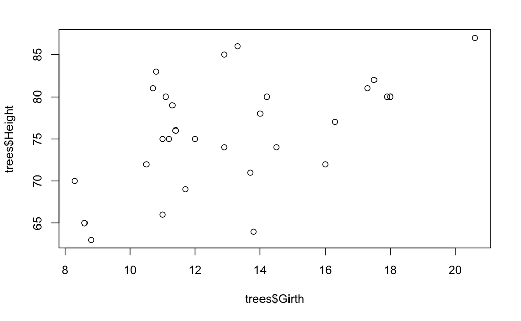

```r
#x,y interface
plot(trees$Girth, trees$Height)
```

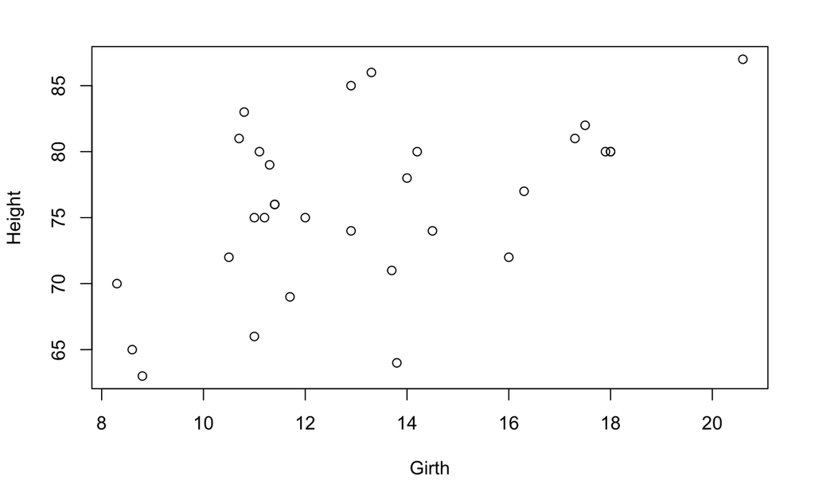

```r
#formula interface
plot(Height ~ Girth, data = trees)
```

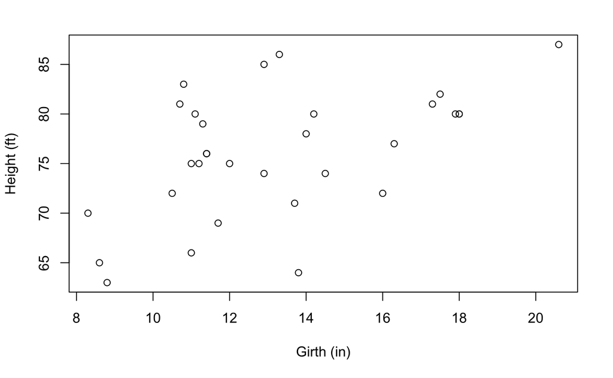

```r
#adding axis labels
plot(Height ~ Girth, data = trees, xlab = "Girth (in)", ylab = "Height (ft)")
```

For correlation, x and y don’t matter, but for regression they do! Checking assumption of bivariate normality should just be done visually (no formal tests for this). Look for outliers, or non-linear patterns in the data.

## Using ggplot2

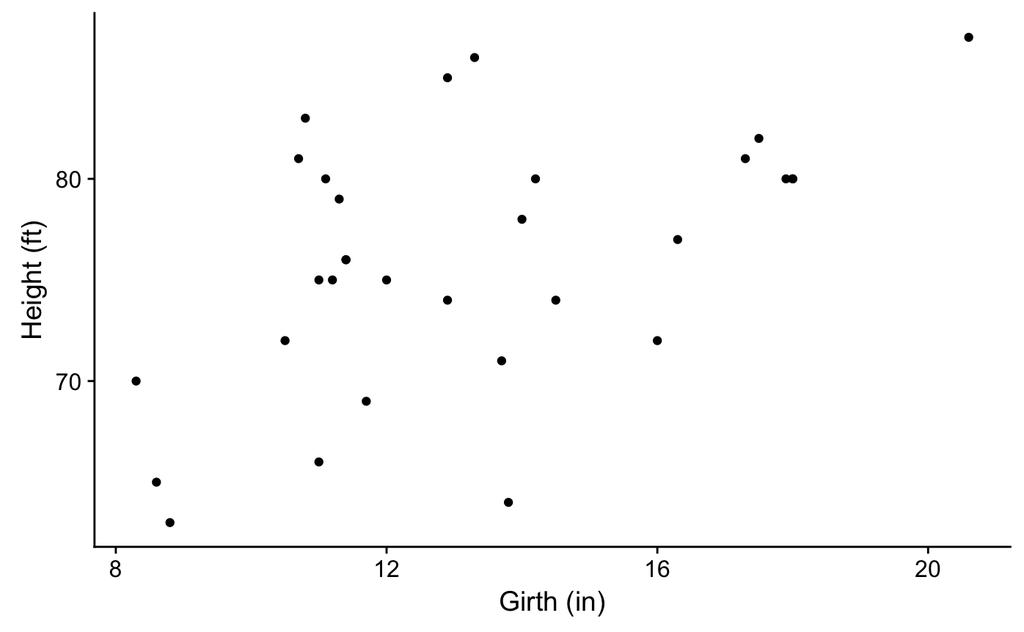

```r
ggplot(trees, aes(x = Girth, y = Height)) +
  geom_point() +
  labs(x = "Girth (in)", y = "Height (ft)")
```

To deal with overplotting you could change the transparency of points with `alpha =` (I also make the size bigger, and the background white in this example so the change in transparency is more obvious).

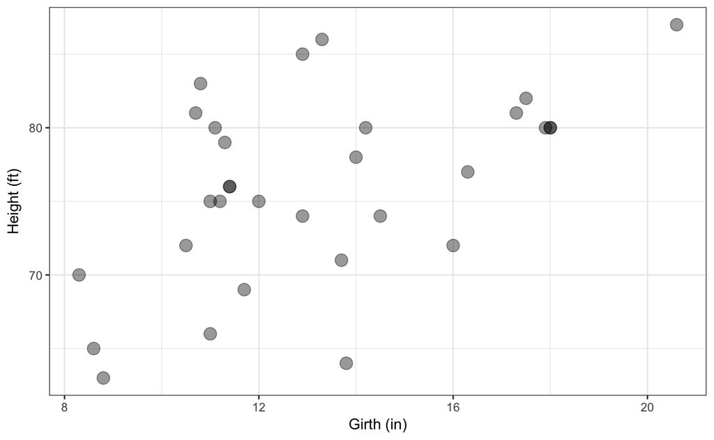

```r
ggplot(trees, aes(x = Girth, y = Height)) +
  geom_point(alpha = 0.4, size = 4) + #alpha sets transparency, size changes point size
  labs(x = "Girth (in)", y = "Height (ft)") +
  theme_bw() #just changes the appearance of the plot
```

# Pearson correlation

## Get a correlation coefficient

`cor()` only returns a correlation coefficient. It’s useful because it returns only a single thing compared to `cor.test()`. This could come in handy if you wanted to calculate a bunch of correlation coefficients. You can also use it on a data frame and get all pairwise correlations.

```r
cor(trees$Girth, trees$Height, method = "pearson")
```

```
[1] 0.5192801
```

```r
cor(trees)
```

```
           Girth    Height    Volume
Girth  1.0000000 0.5192801 0.9671194
Height 0.5192801 1.0000000 0.5982497
Volume 0.9671194 0.5982497 1.0000000
```

## Hypothesis testing

```r
cor.test(trees$Girth, trees$Height, method = "pearson")
```

```
    Pearson's product-moment correlation

data:  trees$Girth and trees$Height
t = 3.2722, df = 29, p-value = 0.002758
alternative hypothesis: true correlation is not equal to 0
95 percent confidence interval:
 0.2021327 0.7378538
sample estimates:
      cor
0.5192801
```

The default method is pearson, but just for clarity, I’ve written it in the code.

What to report:

- Test statistic r (“cor” in the R output)
- N or df
- p-value

# Spearman correlation

```r
cor(trees$Girth, trees$Height, method = "spearman")
```

```
[1] 0.4408387
```

```r
cor.test(trees$Girth, trees$Height, method = "spearman")
```

```
Cannot compute exact p-value with ties
```

```
    Spearman's rank correlation rho

data:  trees$Girth and trees$Height
S = 2773.4, p-value = 0.01306
alternative hypothesis: true rho is not equal to 0
sample estimates:
      rho
0.4408387
```

What to report:

- r_s (“rho” in the R output)
- N or df
- p-value

# Exercise

Test the hypothesis that ITS and nectar return are correlated using the bee data

## Plot to check assumptions

```r
bees
```

| Colony | BeeID | Pollen | ITS | Nectar |
| --- | --- | --- | --- | --- |
| 57 | B91 | 0.00000 | 4.03 | 0.00027 |
| 41 | 838E52010B000000 | 0.00153 | 2.87 | 0.00033 |
| 41 | 798C52010B000000 | 0.02089 | 3.19 | 0.00035 |
| 57 | B58 | 0.00034 | 3.07 | 0.00063 |
| 58 | G49 | 0.00000 | 3.42 | 0.00065 |
| 32 | R24 | 0.02855 | 3.86 | 0.00114 |
| 58 | G31 | 0.00000 | 4.34 | 0.00132 |
| 57 | B59 | 0.00000 | 3.61 | 0.00155 |
| 57 | B53 | 0.00000 | 3.71 | 0.00196 |
| 57 | B79 | 0.00000 | 4.01 | 0.00246 |

[output cut: 514 more lines]

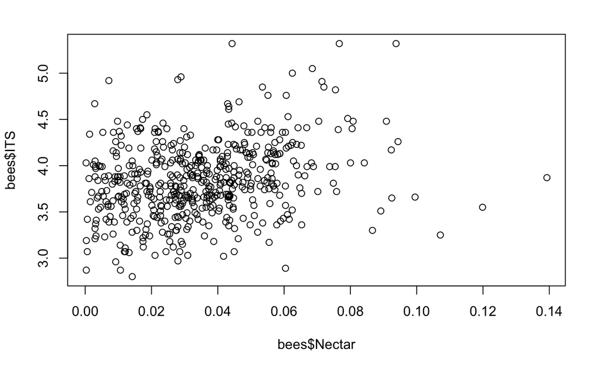

```r
plot(bees$Nectar, bees$ITS)
```

Looks like a linear relationship. Possibly some outliers with extreme values for nectar. Data seems truncated at 0. We could try a data transformation or go with a non-parametric method. Square root transformed nectar returns looks better.

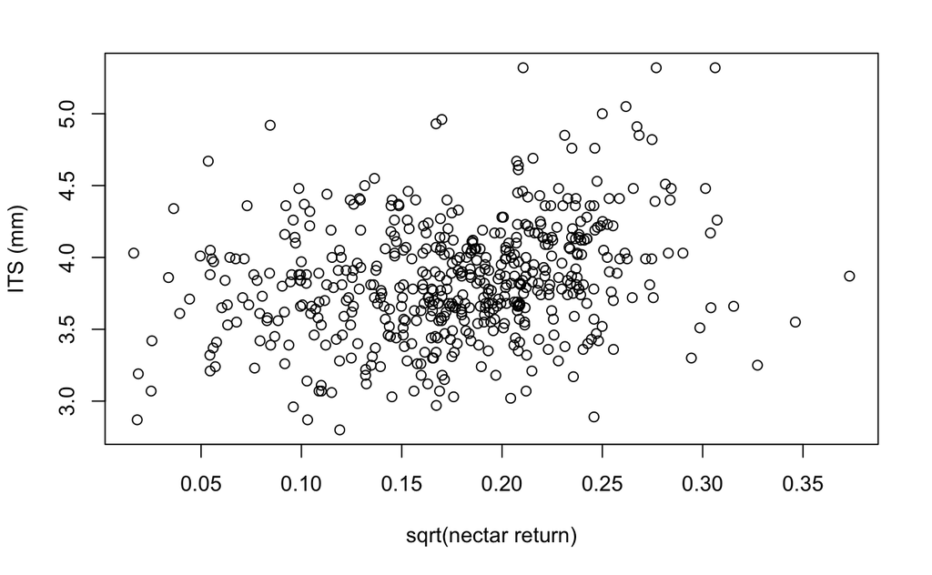

```r
plot(sqrt(bees$Nectar), bees$ITS, xlab = "sqrt(nectar return)", ylab = "ITS (mm)")
```

## Pearson product-moment correlation

Using sqrt transformed nectar data

```r
bee.cortest <- cor.test(sqrt(bees$Nectar), bees$ITS, method = "pearson")
bee.cortest
```

```
    Pearson's product-moment correlation

data:  sqrt(bees$Nectar) and bees$ITS
t = 6.0844, df = 521, p-value = 2.266e-09
alternative hypothesis: true correlation is not equal to 0
95 percent confidence interval:
 0.1757109 0.3358910
sample estimates:
      cor
0.2575697
```

```r
bee.cortest$estimate^2 #r-squared
```

```
       cor
0.06634213
```

Statistically significant, but pretty weak correlation

## Spearman rank correlation

Using non-parametric method on untransformed data is also a viable option

```r
cor.test(bees$Nectar, bees$ITS, method = "spearman")
```

```
Cannot compute exact p-value with ties
```

```
    Spearman's rank correlation rho

data:  bees$Nectar and bees$ITS
S = 17761000, p-value = 3.268e-09
alternative hypothesis: true rho is not equal to 0
sample estimates:
      rho
0.2550748
```

Statistically significant relationship, but very weak correlation.